# Exhaustion2

LinyiGuo

2019/10/21

The datasets I used before is ‘multiplicative’, which is not traditional case I learned so far. Although I thought it wasn’t complex when dealing with, it is not easy, at least the result is not good.(**Comment: I was wrong before cause I forgot the negative sign in seasonal component expression, and this is the reason why the curves behave bad. (2019.10.23)** )

I am going to use the dataset ‘unemp’ in ‘seasonal’ package in this document at first.

```r
unemp_x11 <- seas(unemp, x11='')
unemp_ssmm <- SSModel(unemp ~ SSMtrend(1,Q=list(1)) +
                        SSMseasonal(12, Q=1, sea.type = 'dummy'), H=1)
unemp_ssm <- KFS(unemp_ssmm)
```

We let variances to be (1,1,1) at first and results will be:

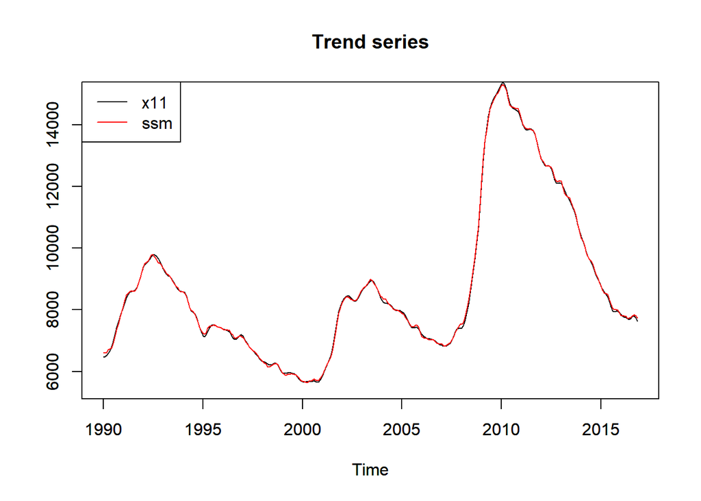

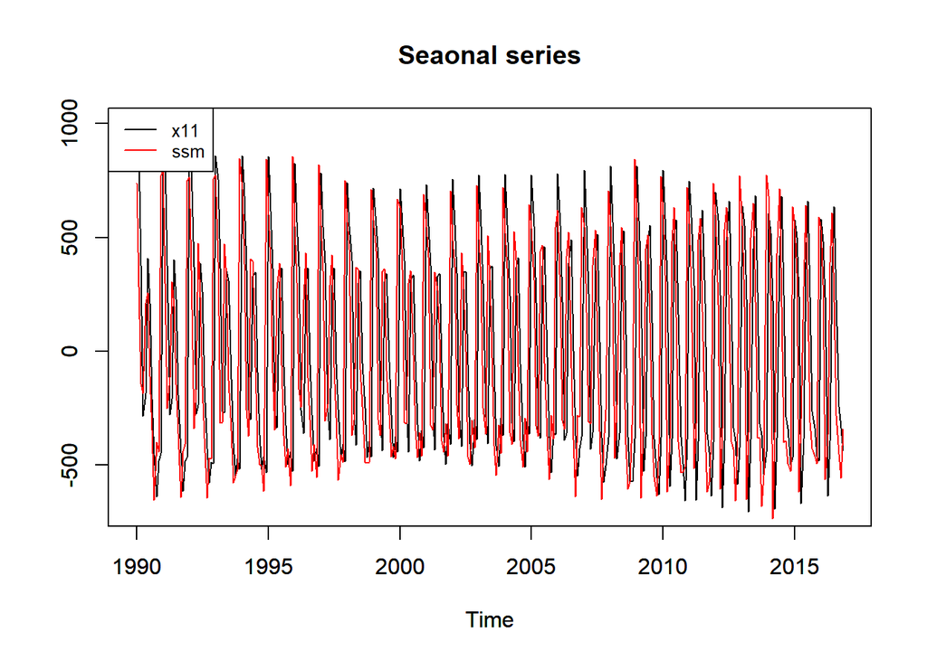

Extract the first 100 points:

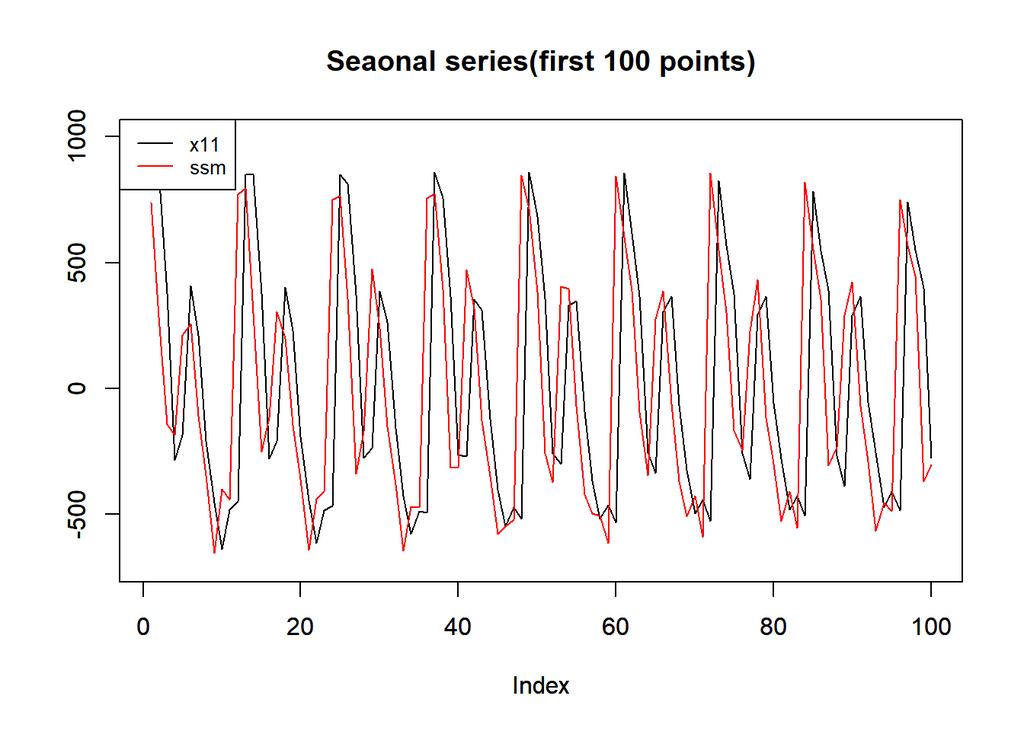

**Problem:** the seasonal curve of ssm is ahead of that of x11 with one unit(one month). And this occured before in the statcan retailsales case(total) too.

We abandon the first point in x11 results and the last one in ssm, then their results are pretty close.

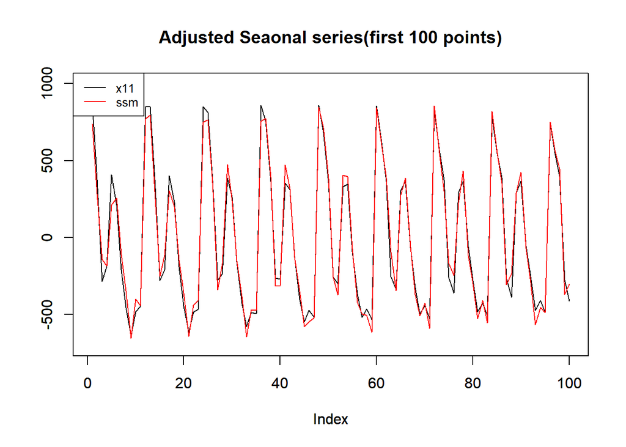

[figure not shown]

```r
plot(unemp_x11_seasonal[-1][1:100], ylim=c(-700,1000), ylab='', type='l')
par(new=TRUE)
plot(unemp_ssm_seasonal[-length(unemp)][1:100], ylim=c(-700,1000),
     ylab='',type='l', col=2)
title(main = 'Adjusted Seaonal series(first 100 points)')
legend('topleft', c('x11','ssm'), col=c(1,2), lty=1, cex=.8)
```

This result looks better than that of multiplicative cases.

# Find the ‘ideal’ parameters’ values

Here, I use the product of the sum of squared differences between x11 and ssm, that is:
$$\sum(X11_{trend}-SSM_{trend})^2 * \sum(X11_{seasonal}-SSM_{seasonal})^2 * \sum(X11_{seasadj}-SSM_{seasadj})^2$$

And naturally, we perfer to choose the parameter corresponding to the **smallest** value.

```r
# define our standard to choose parameters
# note this is for additive models
Dif <- function(x11, ssm, data){

  x11_trend <- series(x11, 'd12')
  x11_seasonal <- series(x11, 'd10')
  x11_seasadj <- series(x11, 'd11')

  ssm_trend <- coef(ssm, states = 'trend')
  ssm_seasonal <- -rowSums(coef(ssm, states='seasonal'))
  ssm_seasadj <- data[-1] - ssm_seasonal[-length(data)] # length is shorter

  D <-  sum((x11_trend-ssm_trend)^2) *
    sum((x11_seasonal[-1]-ssm_seasonal[-length(data)])^2) *
    sum((x11_seasadj[-1]-ssm_seasadj)^2)
  return(D)
}
```

Here we let the variance to be *0.001, 0.01, 0.1, 1, 10, 100*.

```r
# define the search function
exhaustion <- function(data){

  Difference <- c()
  index <- c()

  x11 <- seas(data, x11='')
   for (i in 1:6) {
     for (j in 1:6) {
       for (k in 1:6) {

           ssmm <- SSModel(data ~ SSMtrend(1, Q=list(10^(-4+j))) +
                     SSMseasonal(12, sea.type = 'dummy', Q = 10^(-4+k)),
                   H = 10^(-4+i))
           ssm <- KFS(ssmm)

           dif <- Dif(x11, ssm, data)

           Difference <- c(Difference, dif)

           index <- rbind(index, c(10^(-4+i),10^(-4+j),10^(-4+k)))
         }
      }
   }

  df <- data.frame(variance=index, difference = Difference)
  return(df)
}
```

```r
unemp_exhaustion <- exhaustion(unemp)
unemp_exhaustion[which.min(unemp_exhaustion$difference),]
```

```
##     variance.1 variance.2 variance.3   difference
## 173         10         10         10 1.237124e+18
```

```r
unemp_ssmm <- SSModel(unemp ~ SSMtrend(1,Q=list(10)) +
                        SSMseasonal(12, Q=10, sea.type = 'dummy'), H=10)
unemp_ssm <- KFS(unemp_ssmm)
```

```r
unemp_ssm_trend <- coef(unemp_ssm, states = 'trend')
unemp_ssm_seasonal <- ts(-rowSums(coef(unemp_ssm, states = 'seasonal')),
                       start = c(1990,1), frequency = 12)
unemp_ssm_seasadj <- unemp[-1] - unemp_ssm_seasonal[-length(unemp)]
```

Here are results:

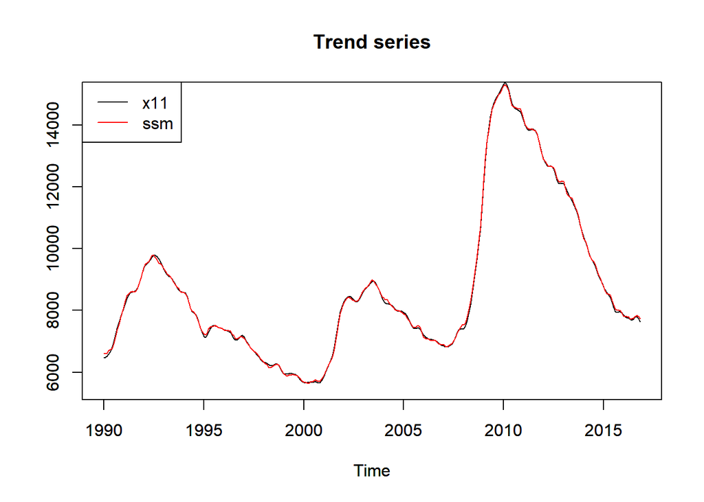

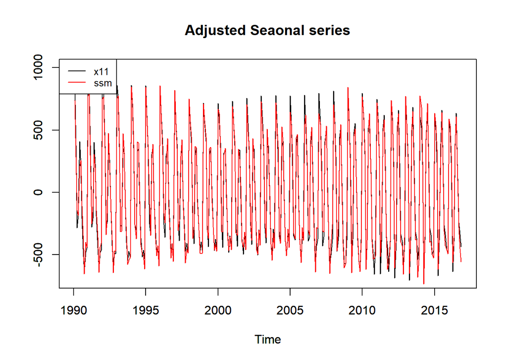

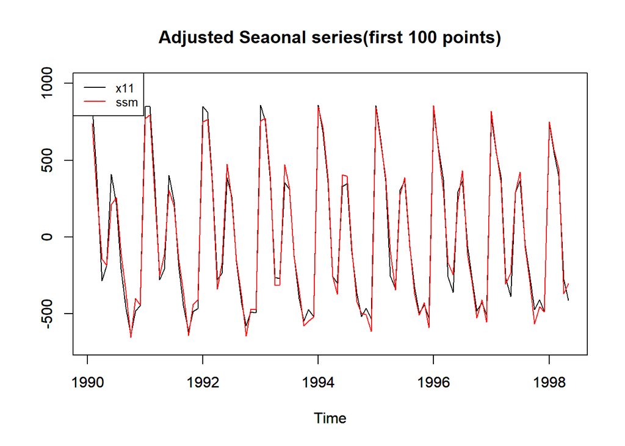

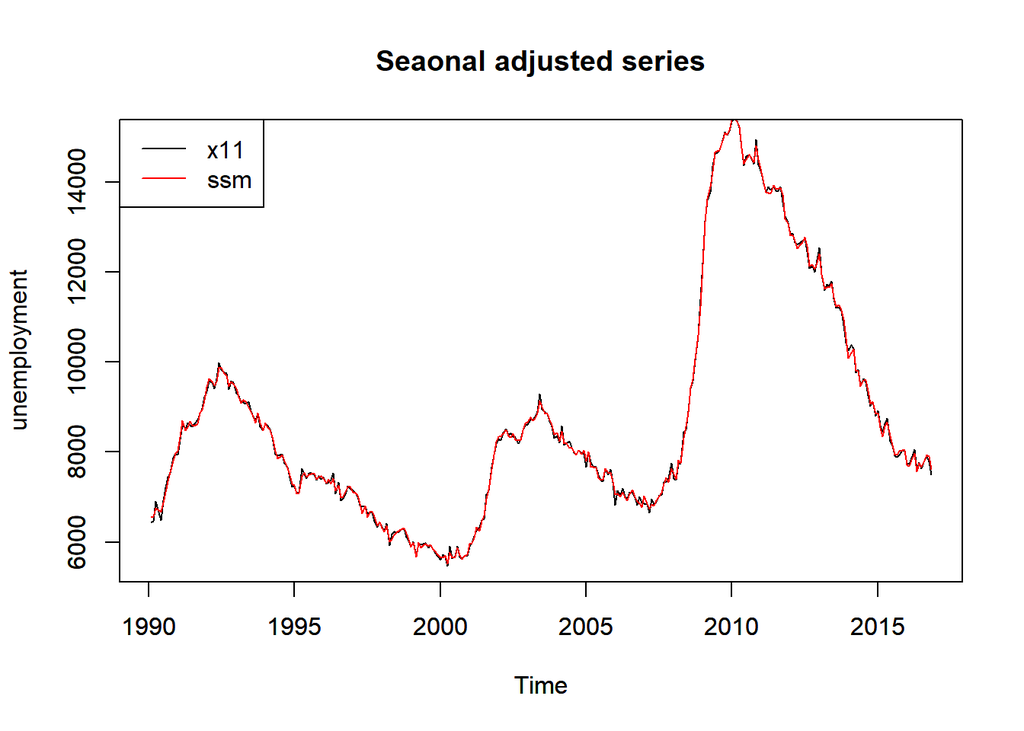

Let’s suppose the best value of parameters are (10,10,10) in *unemp* dataset.

What we want to do then is get the similar result given by bayesian without help of *seasonal* package.

# Continued in MLE&MAP4